# Part I - Ford GoBike System Data

## Introduction:

> Ford GoBike System Data exploration describes the exploration of data of riders obtained in a bike-sharing system covering the greater San Francisco Bay area. In this dataset, we would clean, visualize and draw useful insight.

```python
# import all packages and set plots to be embedded inline
import pandas as pd
import numpy as np
import matplotlib.pyplot as plt
%matplotlib inline
import calendar
import seaborn as sb
from math import radians, sin, cos, sqrt, atan2
```

```python
# load in the dataset into a pandas dataframe
bike = pd.read_csv('201902-fordgobike-tripdata (1).csv')
```

## Assessing Data

- In this section, I need to assess the dataset to gather more information on number of columns, rows, the statistics of each data in each dataframe, shapes, data types and others.
- I will also check for missing values, duplicated data, unique values and other necessary parameters

```python
bike.head()
```

|  | duration_sec | start_time | end_time | start_station_id | start_station_name | start_station_latitude | start_station_longitude | end_station_id | end_station_name | end_station_latitude | end_station_longitude | bike_id | user_type | member_birth_year | member_gender | bike_share_for_all_trip |
| --- | --- | --- | --- | --- | --- | --- | --- | --- | --- | --- | --- | --- | --- | --- | --- | --- |
| 0 | 52185 | 2019-02-28 17:32:10.1450 | 2019-03-01 08:01:55.9750 | 21.0 | Montgomery St BART Station (Market St at 2nd St) | 37.789625 | -122.400811 | 13.0 | Commercial St at Montgomery St | 37.794231 | -122.402923 | 4902 | Customer | 1984.0 | Male | No |
| 1 | 42521 | 2019-02-28 18:53:21.7890 | 2019-03-01 06:42:03.0560 | 23.0 | The Embarcadero at Steuart St | 37.791464 | -122.391034 | 81.0 | Berry St at 4th St | 37.775880 | -122.393170 | 2535 | Customer | NaN | NaN | No |
| 2 | 61854 | 2019-02-28 12:13:13.2180 | 2019-03-01 05:24:08.1460 | 86.0 | Market St at Dolores St | 37.769305 | -122.426826 | 3.0 | Powell St BART Station (Market St at 4th St) | 37.786375 | -122.404904 | 5905 | Customer | 1972.0 | Male | No |
| 3 | 36490 | 2019-02-28 17:54:26.0100 | 2019-03-01 04:02:36.8420 | 375.0 | Grove St at Masonic Ave | 37.774836 | -122.446546 | 70.0 | Central Ave at Fell St | 37.773311 | -122.444293 | 6638 | Subscriber | 1989.0 | Other | No |
| 4 | 1585 | 2019-02-28 23:54:18.5490 | 2019-03-01 00:20:44.0740 | 7.0 | Frank H Ogawa Plaza | 37.804562 | -122.271738 | 222.0 | 10th Ave at E 15th St | 37.792714 | -122.248780 | 4898 | Subscriber | 1974.0 | Male | Yes |

```python
bike.shape
```

```
(183412, 16)
```

```python
bike.info()
```

```
<class 'pandas.core.frame.DataFrame'>
RangeIndex: 183412 entries, 0 to 183411
Data columns (total 16 columns):
 #   Column                   Non-Null Count   Dtype
---  ------                   --------------   -----
 0   duration_sec             183412 non-null  int64
 1   start_time               183412 non-null  object
 2   end_time                 183412 non-null  object
 3   start_station_id         183215 non-null  float64
 4   start_station_name       183215 non-null  object
 5   start_station_latitude   183412 non-null  float64
 6   start_station_longitude  183412 non-null  float64
 7   end_station_id           183215 non-null  float64
 8   end_station_name         183215 non-null  object
 9   end_station_latitude     183412 non-null  float64
 10  end_station_longitude    183412 non-null  float64
 11  bike_id                  183412 non-null  int64
 12  user_type                183412 non-null  object
 13  member_birth_year        175147 non-null  float64
 14  member_gender            175147 non-null  object
 15  bike_share_for_all_trip  183412 non-null  object
dtypes: float64(7), int64(2), object(7)
memory usage: 22.4+ MB
```

```python
bike.sample(6)
```

|  | duration_sec | start_time | end_time | start_station_id | start_station_name | start_station_latitude | start_station_longitude | end_station_id | end_station_name | end_station_latitude | end_station_longitude | bike_id | user_type | member_birth_year | member_gender | bike_share_for_all_trip |
| --- | --- | --- | --- | --- | --- | --- | --- | --- | --- | --- | --- | --- | --- | --- | --- | --- |
| 175297 | 385 | 2019-02-02 14:50:20.7070 | 2019-02-02 14:56:45.9310 | 252.0 | Channing Way at Shattuck Ave | 37.865847 | -122.267443 | 239.0 | Bancroft Way at Telegraph Ave | 37.868813 | -122.258764 | 2649 | Subscriber | 1995.0 | Male | No |
| 106706 | 302 | 2019-02-13 17:44:05.7820 | 2019-02-13 17:49:08.3620 | 147.0 | 29th St at Tiffany Ave | 37.744067 | -122.421472 | 127.0 | Valencia St at 21st St | 37.756708 | -122.421025 | 5036 | Subscriber | 1994.0 | Male | No |
| 109141 | 611 | 2019-02-12 19:49:03.5930 | 2019-02-12 19:59:14.7930 | 273.0 | Fulton St at Ashby Ave | 37.855574 | -122.263565 | 157.0 | 65th St at Hollis St | 37.846784 | -122.291376 | 5144 | Subscriber | 1980.0 | Female | No |
| 27935 | 404 | 2019-02-25 09:07:29.3160 | 2019-02-25 09:14:13.7530 | 10.0 | Washington St at Kearny St | 37.795393 | -122.404770 | 20.0 | Mechanics Monument Plaza (Market St at Bush St) | 37.791300 | -122.399051 | 5813 | Subscriber | 1973.0 | Male | No |
| 127996 | 947 | 2019-02-10 14:13:00.8260 | 2019-02-10 14:28:48.5640 | 157.0 | 65th St at Hollis St | 37.846784 | -122.291376 | 351.0 | 10th St at University Ave | 37.869060 | -122.293400 | 5430 | Customer | 1992.0 | Male | No |
| 181238 | 518 | 2019-02-01 09:20:36.1470 | 2019-02-01 09:29:14.5200 | 81.0 | Berry St at 4th St | 37.775880 | -122.393170 | 61.0 | Howard St at 8th St | 37.776513 | -122.411306 | 5283 | Subscriber | 1988.0 | Male | No |

```python
# Get an overview on the statistics of the dataset
bike.describe()
```

|  | duration_sec | start_station_id | start_station_latitude | start_station_longitude | end_station_id | end_station_latitude | end_station_longitude | bike_id | member_birth_year |
| --- | --- | --- | --- | --- | --- | --- | --- | --- | --- |
| count | 183412.000000 | 183215.000000 | 183412.000000 | 183412.000000 | 183215.000000 | 183412.000000 | 183412.000000 | 183412.000000 | 175147.000000 |
| mean | 726.078435 | 138.590427 | 37.771223 | -122.352664 | 136.249123 | 37.771427 | -122.352250 | 4472.906375 | 1984.806437 |
| std | 1794.389780 | 111.778864 | 0.099581 | 0.117097 | 111.515131 | 0.099490 | 0.116673 | 1664.383394 | 10.116689 |
| min | 61.000000 | 3.000000 | 37.317298 | -122.453704 | 3.000000 | 37.317298 | -122.453704 | 11.000000 | 1878.000000 |
| 25% | 325.000000 | 47.000000 | 37.770083 | -122.412408 | 44.000000 | 37.770407 | -122.411726 | 3777.000000 | 1980.000000 |
| 50% | 514.000000 | 104.000000 | 37.780760 | -122.398285 | 100.000000 | 37.781010 | -122.398279 | 4958.000000 | 1987.000000 |
| 75% | 796.000000 | 239.000000 | 37.797280 | -122.286533 | 235.000000 | 37.797320 | -122.288045 | 5502.000000 | 1992.000000 |
| max | 85444.000000 | 398.000000 | 37.880222 | -121.874119 | 398.000000 | 37.880222 | -121.874119 | 6645.000000 | 2001.000000 |

```python
# Check for sum of missing data for rows and columns in the pisa dataset
print(sum(bike.isnull().values.any(axis=0)))

# Check for sum of missing data for rows in the pisa dataset
sum(bike.isnull().values.any(axis=1))
```

```
6
```

```
8460
```

```python
# Check for the sum of duplicated values
sum(bike.duplicated())
```

```
0
```

```python
bike['duration_sec'].sort_values(ascending=False)
```

```
101361    85444
85465     84548
153705    83772
127999    83519
112435    83407
          ...
19581        61
44787        61
64088        61
18578        61
58992        61
Name: duration_sec, Length: 183412, dtype: int64
```

```python
print(bike.start_time.unique())
print(bike.end_time.unique())
```

```
['2019-02-28 17:32:10.1450' '2019-02-28 18:53:21.7890'
 '2019-02-28 12:13:13.2180' ... '2019-02-01 00:06:05.5490'
 '2019-02-01 00:05:34.3600' '2019-02-01 00:00:20.6360']
['2019-03-01 08:01:55.9750' '2019-03-01 06:42:03.0560'
 '2019-03-01 05:24:08.1460' ... '2019-02-01 00:08:27.2200'
 '2019-02-01 00:07:54.2870' '2019-02-01 00:04:52.0580']
```

```python
bike.member_birth_year.unique()
```

```
array([1984.,   nan, 1972., 1989., 1974., 1959., 1983., 1988., 1992.,
       1996., 1993., 1990., 1981., 1975., 1978., 1991., 1997., 1986.,
       2000., 1982., 1995., 1980., 1973., 1985., 1971., 1979., 1967.,
       1998., 1994., 1977., 1999., 1987., 1969., 1963., 1976., 1964.,
       1965., 1961., 1968., 1966., 1962., 1954., 1958., 1960., 1970.,
       1956., 1957., 1945., 1900., 1952., 1948., 1951., 1941., 1950.,
       1949., 1953., 1955., 1946., 1947., 1931., 1943., 1942., 1920.,
       1933., 2001., 1878., 1901., 1944., 1928., 1934., 1939., 1930.,
       1902., 1910., 1938., 1927.])
```

```python
# Check the unique values in columns to know what is in each column
print(bike.user_type.unique())
print(bike.member_gender.unique())
print(bike.bike_share_for_all_trip.unique())
```

```
['Customer' 'Subscriber']
['Male' nan 'Other' 'Female']
['No' 'Yes']
```

```python
# Check the maximum duration for the bikers to ride a bike
bike['duration_sec'].max()
```

```
85444
```

```python
sum(bike.member_gender.isnull())
```

```
8265
```

```python
df = bike.copy()
```

### Identifying the Quality and Tidiness issues

### Issues

Quality Issues

- Check for the columns with null or missing values and drop them all
- The distance covered by each bike cannot be deduced. So craete another variable called distance and calculate the distance covered by each bike from the Lattitude and longitude variables.
- Change the datatype of start_time and end_time to datetime and member_birth_year to integer
- Rename columns for better representation
- Drop the outlier in the duration_sec column
- Drop all unnecessary columns, columns not needed

Tidiness Issues: Feature Engineering

- Get the month, weekday and day from the start_time column
- Get the age of the riders from birth_year into a column called age
- Deduce the how long in mins it takes for each biker to ride a bike

### Issue 1: Check for the columns with null or missing values and drop them all

```python
# check for the columns with null values
(df.isna().sum())/(len(df))*100
```

```
duration_sec               0.000000
start_time                 0.000000
end_time                   0.000000
start_station_id           0.107408
start_station_name         0.107408
start_station_latitude     0.000000
start_station_longitude    0.000000
end_station_id             0.107408
end_station_name           0.107408
end_station_latitude       0.000000
end_station_longitude      0.000000
bike_id                    0.000000
user_type                  0.000000
member_birth_year          4.506248
member_gender              4.506248
bike_share_for_all_trip    0.000000
dtype: float64
```

#### Comment 1:

> There are missing values/null values in the following columns: start_station_id, start_station_name,end_station_id, end_station_name, member_birth_year and member_gender

```python
# Drop the null values
df.dropna(inplace=True)
```

```python
df.info()
```

```
<class 'pandas.core.frame.DataFrame'>
Int64Index: 174952 entries, 0 to 183411
Data columns (total 16 columns):
 #   Column                   Non-Null Count   Dtype
---  ------                   --------------   -----
 0   duration_sec             174952 non-null  int64
 1   start_time               174952 non-null  object
 2   end_time                 174952 non-null  object
 3   start_station_id         174952 non-null  float64
 4   start_station_name       174952 non-null  object
 5   start_station_latitude   174952 non-null  float64
 6   start_station_longitude  174952 non-null  float64
 7   end_station_id           174952 non-null  float64
 8   end_station_name         174952 non-null  object
 9   end_station_latitude     174952 non-null  float64
 10  end_station_longitude    174952 non-null  float64
 11  bike_id                  174952 non-null  int64
 12  user_type                174952 non-null  object
 13  member_birth_year        174952 non-null  float64
 14  member_gender            174952 non-null  object
 15  bike_share_for_all_trip  174952 non-null  object
dtypes: float64(7), int64(2), object(7)
memory usage: 22.7+ MB
```

```python
# Check the null values again in member_gender
sum(df.member_gender.isnull())
```

```
0
```

### Issue 2: Change the datatype of start_time and end_time to datetime and member_birth_year to integer

```python
df.start_time = df['start_time'].astype('datetime64[ns]')
df.end_time = df['end_time'].astype('datetime64[ns]')
df.member_birth_year = df['member_birth_year'].astype("int")
```

### Issue 3: Calculate the distance covered from the latitude and longitude given

Ref: https://stackoverflow.com/questions/19412462/getting-distance-between-two-points-based-on-latitude-longitude

```python
def distance(start, end):

    lat1, long1 = start
    lat2, long2 = end
    radius = 6371 # Approximate raidius of the earth

    dlat = radians(lat2 - lat1)
    dlong = radians(long2 - long1)

    a = (sin(dlat / 2) * sin(dlat / 2) + cos(radians(lat1)) * cos(radians(lat2)) * sin(dlong / 2) * sin(dlong / 2))
    c = 2 * atan2(sqrt(a), sqrt(1 - a))
    distance = radius * c

    # Round up the values to two decimal places
    return round(distance, 2)
```

```python
df['distance_km'] = df.apply(lambda x: distance((x['start_station_latitude'], x['start_station_longitude']),
                                                            (x['end_station_latitude'], x['end_station_longitude'])),
                                         axis=1)
```

### Issue 4a: Get the month, weekday and day from the start_time column

```python
df['st_month_name']=df['start_time'].dt.strftime('%B')
df['st_time_weekday']=df['start_time'].dt.strftime('%a')
df['st_time_day']=df['start_time'].dt.day.astype(int)

df.rename(columns={'st_month_name':'month',
                          'st_time_weekday':'weekday',
                          'st_time_day':'day'},inplace=True)
```

### Issue 5: Rename columns for better representation

```python
df.rename(columns={'member_birth_year': 'birth_year','bike_share_for_all_trip': 'bike_share', 'member_gender': 'gender'},
          inplace=True)
```

```python
# check if the distance_km column, month, weekday and day have been included
df.info()
```

```
<class 'pandas.core.frame.DataFrame'>
Int64Index: 174952 entries, 0 to 183411
Data columns (total 20 columns):
 #   Column                   Non-Null Count   Dtype
---  ------                   --------------   -----
 0   duration_sec             174952 non-null  int64
 1   start_time               174952 non-null  datetime64[ns]
 2   end_time                 174952 non-null  datetime64[ns]
 3   start_station_id         174952 non-null  float64
 4   start_station_name       174952 non-null  object
 5   start_station_latitude   174952 non-null  float64
 6   start_station_longitude  174952 non-null  float64
 7   end_station_id           174952 non-null  float64
 8   end_station_name         174952 non-null  object
 9   end_station_latitude     174952 non-null  float64
 10  end_station_longitude    174952 non-null  float64
 11  bike_id                  174952 non-null  int64
 12  user_type                174952 non-null  object
 13  birth_year               174952 non-null  int32
 14  gender                   174952 non-null  object
 15  bike_share               174952 non-null  object
 16  distance_km              174952 non-null  float64
 17  month                    174952 non-null  object
 18  weekday                  174952 non-null  object
 19  day                      174952 non-null  int32
dtypes: datetime64[ns](2), float64(7), int32(2), int64(2), object(7)
memory usage: 26.7+ MB
```

### Issue 6: Get the age of the riders from birth_year into a column called age

```python
# Deduct the biker's birth year from the current year to deduce their age
df['age'] = 2021 - df['birth_year']
```

```python
# Use the describe function to deduce the maximum age of bikers
df.age.describe()
```

```
count    174952.000000
mean         36.196865
std          10.118731
min          20.000000
25%          29.000000
50%          34.000000
75%          41.000000
max         143.000000
Name: age, dtype: float64
```

#### Comment 2:

- It can be seen that the maximum age here is 143 which is impossible for a person of age 143yrs to ride a bike.

```python
# Sort the age of the bikers in decending order to know the age of the old bikers
df.age.sort_values(ascending = False)
```

```
27370     143
10827     121
110468    121
122194    121
163112    121
         ...
63137      20
39355      20
111857     20
181314     20
84682      20
Name: age, Length: 174952, dtype: int32
```

#### Comment 3:

- So we can see that we have bikers that are above 100years of age.
- So let us limit the age of all riders to about 72years

```python
# Let's check and select the data for member_age less than or equal to 72yrs
df = df.query("age <= 72")

# Now, let's check it the selection has been done
df.age.describe()
```

```
count    174377.000000
mean         36.038876
std           9.714521
min          20.000000
25%          29.000000
50%          34.000000
75%          41.000000
max          72.000000
Name: age, dtype: float64
```

### Issue 7: Drop the outlier in the duration_sec column

```python
df['duration_sec'].describe()
```

```
count    174377.000000
mean        704.259535
std        1644.215551
min          61.000000
25%         323.000000
50%         511.000000
75%         789.000000
max       84548.000000
Name: duration_sec, dtype: float64
```

#### Comment 4:

> - The increase in riders duration from 789sec to 84548sec calls for concern.
> - It looks to me that this is an outlier. Let's check the 99% to have an overview of the duration

```python
df['duration_sec'].describe([.99])
```

```
count    174377.000000
mean        704.259535
std        1644.215551
min          61.000000
50%         511.000000
99%        3175.240000
max       84548.000000
Name: duration_sec, dtype: float64
```

#### Comment 5:

> - Our prediction is correct. There can't be a jump from 3175sec to 84548sec. That should definitely be an outlier.
> - Let's take step(s) to remove the outlier by restricting the duration for the biker's ride. This can be done by rounding off the 99% value to the nearest value (3180sec).

```python
# Let's check and select the data for duration_sec less than or equal to 3180sec
df = df.query("duration_sec <= 3180")

# Now, let's check it the selection has been done
df.duration_sec.describe()
```

```
count    172638.000000
mean        612.920533
std         425.744349
min          61.000000
25%         321.000000
50%         506.000000
75%         777.000000
max        3178.000000
Name: duration_sec, dtype: float64
```

### Issue 8: Deduce the how long in mins it takes for each biker to ride a bike

```python
# This can be deduce from the duration sec. Convert the sec to minutes by dividing the sec by 60.
df['duration_min'] = df['duration_sec']/60
```

```python
# Verify that this is done
assert 'duration_min' in list (df)
```

```python
# Check the statistics of the duration_min column
df['duration_min'].describe()
```

```
count    172638.000000
mean         10.215342
std           7.095739
min           1.016667
25%           5.350000
50%           8.433333
75%          12.950000
max          52.966667
Name: duration_min, dtype: float64
```

### Issue 9: Drop all unnecessary columns, columns not needed

```python
df.drop(['start_station_id', 'end_station_id', 'bike_id'], axis = 1, inplace = True)
```

```python
df.info()
```

```
<class 'pandas.core.frame.DataFrame'>
Int64Index: 172638 entries, 4 to 183411
Data columns (total 19 columns):
 #   Column                   Non-Null Count   Dtype
---  ------                   --------------   -----
 0   duration_sec             172638 non-null  int64
 1   start_time               172638 non-null  datetime64[ns]
 2   end_time                 172638 non-null  datetime64[ns]
 3   start_station_name       172638 non-null  object
 4   start_station_latitude   172638 non-null  float64
 5   start_station_longitude  172638 non-null  float64
 6   end_station_name         172638 non-null  object
 7   end_station_latitude     172638 non-null  float64
 8   end_station_longitude    172638 non-null  float64
 9   user_type                172638 non-null  object
 10  birth_year               172638 non-null  int32
 11  gender                   172638 non-null  object
 12  bike_share               172638 non-null  object
 13  distance_km              172638 non-null  float64
 14  month                    172638 non-null  object
 15  weekday                  172638 non-null  object
 16  day                      172638 non-null  int32
 17  age                      172638 non-null  int32
 18  duration_min             172638 non-null  float64
dtypes: datetime64[ns](2), float64(6), int32(3), int64(1), object(7)
memory usage: 24.4+ MB
```

```python
df.sample(5)
```

|  | duration_sec | start_time | end_time | start_station_name | start_station_latitude | start_station_longitude | end_station_name | end_station_latitude | end_station_longitude | user_type | birth_year | gender | bike_share | distance_km | month | weekday | day | age | duration_min |
| --- | --- | --- | --- | --- | --- | --- | --- | --- | --- | --- | --- | --- | --- | --- | --- | --- | --- | --- | --- |
| 100442 | 975 | 2019-02-14 18:14:14.116 | 2019-02-14 18:30:29.217 | Howard St at Beale St | 37.789756 | -122.394643 | Mission Bay Kids Park | 37.772301 | -122.393028 | Subscriber | 1987 | Female | No | 1.95 | February | Thu | 14 | 34 | 16.250000 |
| 124139 | 722 | 2019-02-11 08:43:14.900 | 2019-02-11 08:55:16.931 | Precita Park | 37.747300 | -122.411403 | Market St at 10th St | 37.776619 | -122.417385 | Subscriber | 1989 | Male | No | 3.30 | February | Mon | 11 | 32 | 12.033333 |
| 80665 | 673 | 2019-02-18 15:04:40.051 | 2019-02-18 15:15:53.553 | San Fernando St at 4th St | 37.335885 | -121.885660 | Cahill Park | 37.329119 | -121.904576 | Subscriber | 1994 | Male | Yes | 1.83 | February | Mon | 18 | 27 | 11.216667 |
| 114115 | 723 | 2019-02-12 09:56:35.086 | 2019-02-12 10:08:38.632 | Valencia St at Clinton Park | 37.769188 | -122.422285 | Rhode Island St at 17th St | 37.764478 | -122.402570 | Customer | 1980 | Male | No | 1.81 | February | Tue | 12 | 41 | 12.050000 |
| 179598 | 2386 | 2019-02-01 12:46:22.128 | 2019-02-01 13:26:08.902 | 2nd St at Townsend St | 37.780526 | -122.390288 | 2nd St at Townsend St | 37.780526 | -122.390288 | Subscriber | 1994 | Male | No | 0.00 | February | Fri | 1 | 27 | 39.766667 |

```python
# Check for sum of missing data for rows and columns in the bike dataset
print(sum(df.isnull().values.any(axis=0)))

# Check for sum of missing data for rows in the bike dataset
sum(df.isnull().values.any(axis=1))
```

```
0
```

```
0
```

### Storing Data

Save the gathered, assessed, and cleaned bike dataset to a CSV file named "bike_clean.csv".

```python
# Saving the df to a new dataframe
bike_clean = pd.DataFrame(df)

# Save the dataframe into a csv file format
bike_clean.to_csv('bike_clean.csv')
```

```python
# Check the shape of the data after saving it.
print(bike_clean.shape)

bike_clean.head(3)
```

```
(172638, 19)
```

|  | duration_sec | start_time | end_time | start_station_name | start_station_latitude | start_station_longitude | end_station_name | end_station_latitude | end_station_longitude | user_type | birth_year | gender | bike_share | distance_km | month | weekday | day | age | duration_min |
| --- | --- | --- | --- | --- | --- | --- | --- | --- | --- | --- | --- | --- | --- | --- | --- | --- | --- | --- | --- |
| 4 | 1585 | 2019-02-28 23:54:18.549 | 2019-03-01 00:20:44.074 | Frank H Ogawa Plaza | 37.804562 | -122.271738 | 10th Ave at E 15th St | 37.792714 | -122.248780 | Subscriber | 1974 | Male | Yes | 2.41 | February | Thu | 28 | 47 | 26.416667 |
| 5 | 1793 | 2019-02-28 23:49:58.632 | 2019-03-01 00:19:51.760 | 4th St at Mission Bay Blvd S | 37.770407 | -122.391198 | Broadway at Kearny | 37.798014 | -122.405950 | Subscriber | 1959 | Male | No | 3.33 | February | Thu | 28 | 62 | 29.883333 |
| 6 | 1147 | 2019-02-28 23:55:35.104 | 2019-03-01 00:14:42.588 | Palm St at Willow St | 37.317298 | -121.884995 | San Jose Diridon Station | 37.329732 | -121.901782 | Subscriber | 1983 | Female | No | 2.03 | February | Thu | 28 | 38 | 19.116667 |

```python
bike_clean.info()
```

```
<class 'pandas.core.frame.DataFrame'>
Int64Index: 172638 entries, 4 to 183411
Data columns (total 19 columns):
 #   Column                   Non-Null Count   Dtype
---  ------                   --------------   -----
 0   duration_sec             172638 non-null  int64
 1   start_time               172638 non-null  datetime64[ns]
 2   end_time                 172638 non-null  datetime64[ns]
 3   start_station_name       172638 non-null  object
 4   start_station_latitude   172638 non-null  float64
 5   start_station_longitude  172638 non-null  float64
 6   end_station_name         172638 non-null  object
 7   end_station_latitude     172638 non-null  float64
 8   end_station_longitude    172638 non-null  float64
 9   user_type                172638 non-null  object
 10  birth_year               172638 non-null  int32
 11  gender                   172638 non-null  object
 12  bike_share               172638 non-null  object
 13  distance_km              172638 non-null  float64
 14  month                    172638 non-null  object
 15  weekday                  172638 non-null  object
 16  day                      172638 non-null  int32
 17  age                      172638 non-null  int32
 18  duration_min             172638 non-null  float64
dtypes: datetime64[ns](2), float64(6), int32(3), int64(1), object(7)
memory usage: 24.4+ MB
```

### What is the structure of your dataset?

> - Prior to the data wrangling (assessing forr issues and cleaning of data) there were 183412 riders with 16 features/characteristics, giving the information about each biker. These features are ['duration_sec', 'start_time', 'end_time', 'start_station_id', 'start_station_name', 'start_station_latitude', 'start_station_longitude', 'end_station_id','end_station_name', 'end_station_latitude', 'end_station_longitude', 'bike_id', 'user_type','member_birth_year', 'member_gender', 'bike_share_for_all_trip']
> - However, after the data wrangling, some features were removed from the dataset ['start_station_id', 'end_station_id', 'bike_id'] and the dataset now contain information of 172638 bikers with 19 features/characteristics describing each biker.
> - Featured engineering was performed on some of the features and they were added to the remaining features. These engineered variables are age, month, distance_km, weekday, day, duration_min.

### What is/are the main feature(s) of interest in your dataset?

> The main feature of interest is duration taken by bikers for trips. I am interested in other features that distinctively predict the duration of trips in the bike dataset.

### What features in the dataset do you think will help support your investigation into your feature(s) of interest?

> I think the distance_km, the member_age, day and month features in the dataset would help support my investigation.

## Univariate Exploration

### Research Question 1: What is the gender distribution of the riders in the bike-sharing system?

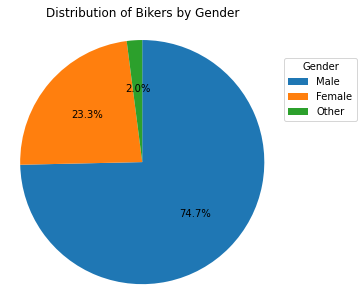

```python
sorted_counts = bike_clean.gender.value_counts()

plt.figure(figsize=(12,5))
plt.pie(sorted_counts, labels = sorted_counts.index, autopct='%1.1f%%',
        startangle = 90, counterclock = False, labeldistance=None);
plt.axis('square');
plt.title("Distribution of Bikers by Gender", pad=10)
plt.legend(title= 'Gender', bbox_to_anchor=(1.3, 0.9), loc='upper right', borderaxespad=0.4);
```

#### Observation 1:

- The bikers in the bike-sharing system are more of male than female. The distribution goes thus: 74.7% male, 23.3% female and others account for 2.0%.

### Research Question 2: Are the riders more subscribers than customers?

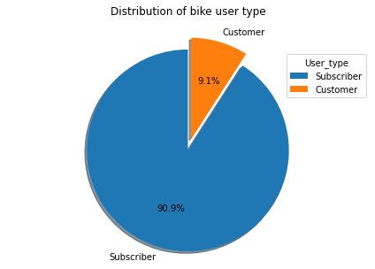

```python
labels = list(bike_clean.user_type.unique())
sizes = bike_clean.user_type.value_counts()
explode = (0.12, 0)

fig1, ax1 = plt.subplots()
ax1.pie(sizes, labels=labels, autopct='%1.1f%%', shadow=True, startangle=90 , explode = explode )
ax1.axis('equal')
plt.tight_layout()
plt.title("Distribution of bike user type", pad= 14)
plt.legend(title= 'User_type', bbox_to_anchor=(1.0, 0.9), loc='upper right', borderaxespad=0.4);
plt.show()
```

#### Observation 2:

- Yes, there are more subscribers than the customers in the bike-sharing system. 90.9% of the riders are subscribers and only 9.1% of the riders are customers.

### Research Question 3: Which day of the week do the bikers prefer to ride the most?

```python
order = bike_clean['weekday'].value_counts().index
order
```

```
Index(['Thu', 'Tue', 'Wed', 'Fri', 'Mon', 'Sun', 'Sat'], dtype='object')
```

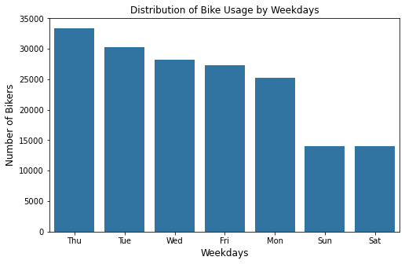

```python
plt.figure(figsize=(8,5))
color = sb.color_palette()[0]
sb.countplot(data=bike_clean, x='weekday', color = color, order = order);
plt.xlabel("Weekdays", fontsize = 12)
plt.ylabel('Number of Bikers',fontsize = 12)
plt.title("Distribution of Bike Usage by Weekdays")
```

#### Observation 3:

- The bikers prefers to ride more on thursdays than any other weekdays

### Research Question 4: What percentage of bikers shared bike in the biking sharing system?

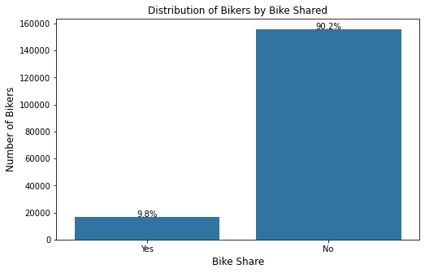

```python
# Calculate the bike_share_counts for clarification.
plt.figure(figsize=(8,5))
bike_share_counts = bike_clean['bike_share'].value_counts()
Total_bike_share = bike_clean['bike_share'].value_counts().sum()

sb.countplot(data=bike_clean, x='bike_share', color = color);
plt.xlabel("Bike Share", fontsize = 12)
plt.ylabel('Number of Bikers',fontsize = 12)
plt.title("Distribution of Bikers by Bike Shared")


# get the current tick locations and labels
locs, labels = plt.xticks()

# loop through each pair of locations and labels
for loc, label in zip(locs, labels):

    # get the text property for the label to get the correct count
    count = bike_share_counts[label.get_text()]
    pct_string = '{:0.1f}%'.format(100*count/Total_bike_share)

    # print the annotation just below the top of the bar
    plt.text(loc, count+2, pct_string, ha = 'center', color = 'black')
```

#### Observation 4:

- Just 9.8% of the bikers love to share bike while majority being 90.2% of the bikers does not like to share bike. Therefore, most bikers prefer to ride alone.

### Research Question 5: What is the age bracket of bikers that ride the most in the biking sharing system?

```python
df.age.describe()
```

```
count    172638.000000
mean         36.033255
std           9.707254
min          20.000000
25%          29.000000
50%          34.000000
75%          41.000000
max          72.000000
Name: age, dtype: float64
```

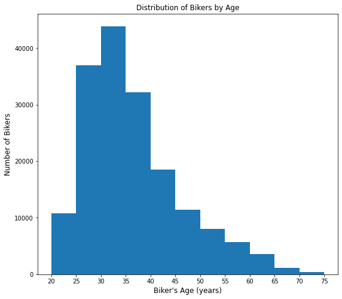

```python
plt.figure(figsize = [9,8])
bins = np.arange(bike_clean.age.min(), bike_clean.age.max()+5, 5)
ticks = [20, 25, 30, 35, 40, 45, 50, 55, 60, 65, 70, 75]
labels = ['{}'. format(v) for v in ticks]
plt.hist(data = bike_clean, x= 'age', bins= bins);
plt.xticks(ticks, labels);
plt.xlabel("Biker's Age (years)", fontsize = 12);
plt.ylabel('Number of Bikers',fontsize = 12);
plt.title("Distribution of Bikers by Age");
```

#### Observation 5:

- The active biders fall in the age bracket between 25yrs to 40yrs. However, the age bracket of bikers that ride the most is between age 30-35yrs; which is the youthful age.

### Research Question 6: What is the distance covered by most bikers in the biking sharing system?

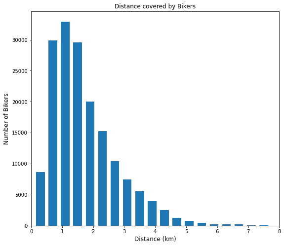

```python
plt.figure(figsize = [9,8])
bins = np.arange(0.1, bike_clean['distance_km'].max()+1, 0.4)
plt.hist(data = bike_clean, x= 'distance_km', bins= bins, rwidth=0.7);
plt.xlim(0, 8)
plt.xlabel("Distance (km)", fontsize = 12);
plt.ylabel('Number of Bikers',fontsize = 12);
plt.title("Distance covered by Bikers");
```

#### Observation 6:

- The distance covered by most bikers in the biking sharing system is between 0.8km and 1.2km. Most bikers prefers to ride for a short distance than a long distance.

### Research Question 7: What is the duration of the rides in the biking sharing system?

```python
bike_clean['duration_min'].describe()
```

```
count    172638.000000
mean         10.215342
std           7.095739
min           1.016667
25%           5.350000
50%           8.433333
75%          12.950000
max          52.966667
Name: duration_min, dtype: float64
```

```python
np.log10(bike_clean['duration_min'].describe())
```

```
count    5.237136
mean     1.009253
std      0.850998
min      0.007179
25%      0.728354
50%      0.925999
75%      1.112270
max      1.724003
Name: duration_min, dtype: float64
```

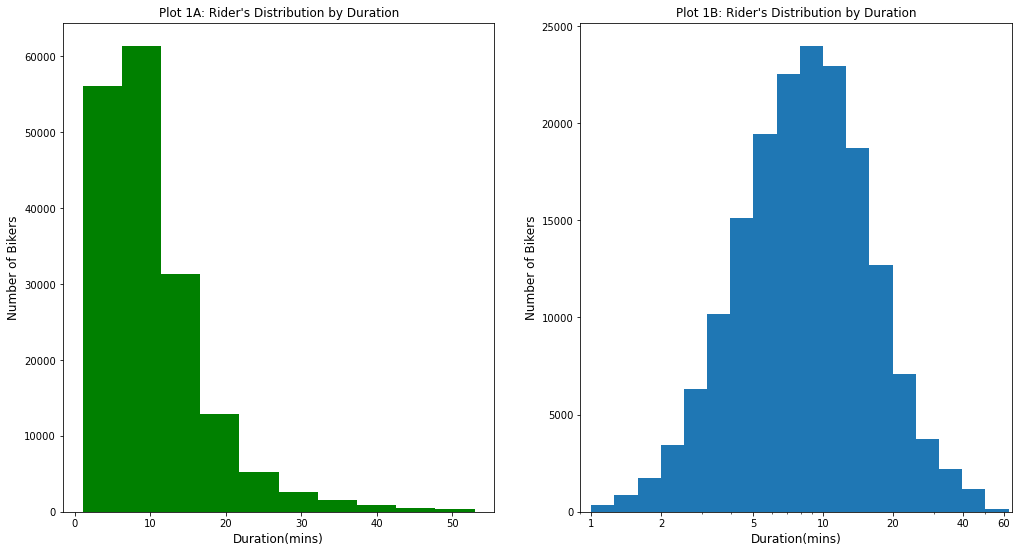

```python
plt.figure(figsize=[17,9])

# HISTOGRAM ON LEFT: full data without scaling
plt.subplot(1, 2, 1)
plt.hist(data= bike_clean, x= 'duration_min', color = 'green');
plt.xlabel('Duration(mins)', fontsize = 12);
plt.ylabel('Number of Bikers',fontsize = 12);
plt.title("Plot 1A: Rider's Distribution by Duration");

# HISTOGRAM ON LEFT: full data with scaling
plt.subplot(1, 2, 2)

# Get the ticks for bins between [0 - maximum weight]
bins = 10 ** np.arange(0, 2+0.1, 0.1)

# Generate the x-ticks you want to apply
ticks = [1, 2, 5, 10, 20, 40, 60]
# Convert ticks into string values, to be displayed long the x-axis
labels = ['{}'.format(v) for v in ticks]

# Plot the histogram
plt.hist(data= bike_clean, x= 'duration_min', bins=bins);

# The argument in the xscale() represents the axis scale type to apply.
# The possible values are: {"linear", "log", "symlog", "logit", ...}
plt.xscale('log')
plt.xlim(0.9, 65)

# Apply x-ticks
plt.xticks(ticks, labels);

plt.xlabel('Duration(mins)', fontsize = 12);
plt.ylabel('Number of Bikers',fontsize = 12);
plt.title("Plot 1B: Rider's Distribution by Duration");
```

#### Observation 7:

- The distribution of the main dataset which is "duration" was plotted. Plot 1A showed the plot distribution before transformation. The distribution seems skewed to the right indcating that most bikers ride for short duration. To get the full grasp of the plot, I performed a log transformation on the plot to generate plot 1B. In Plot 1B, the distribution can be seen clearly. The longest duration the bikers rode for is between 8-12mins according to plot 1B.

### Discuss the distribution(s) of your variable(s) of interest. Were there any unusual points? Did you need to perform any transformations?

> In the variable of interest(duration), the distribution showed that the longest duration the bikers rode for is between 8-12mins. Yes there were unusual points in biker's age and duration_sec variables.

### Of the features you investigated, were there any unusual distributions? Did you perform any operations on the data to tidy, adjust, or change the form of the data? If so, why did you do this?

> Yes there were unusual distribution in the duration_min column. I performed a log transformation to tidy, adjust, or change the form of the data. I did this to have the a clear distribution of the said column.

## Bivariate Exploration

> In this section, I investigated relationships between pairs of variables in my data.

### Research Question 8: Which day of the week do subscribers and customers prefer to ride bikes?

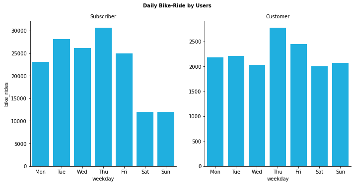

```python
week_order = ['Mon', 'Tue', 'Wed', 'Thu', 'Fri', 'Sat', 'Sun']
draw = sb.catplot(data=bike_clean, x='weekday', col="user_type", kind='count', sharey = False,
            color = 'deepskyblue', order = week_order)
draw.set_axis_labels("weekday", "bike_rides")
draw.set_titles("{col_name}")
draw.fig.suptitle('Daily Bike-Ride by Users', y=1.03, fontsize=10, fontweight='semibold');
```

#### Observation 8:

- For subscribers, they prefer to ride bike on Thursday, so also are the customers too.
- The order for the most preferred week days for subscriber follows the order: Thur > Tue > Wed > Fri > Mon > Sat~Sun. They prefer to ride on Thursdays but not frequently on Saturdays or Sundays.
- for the customers, the order for the most preferred week days follows : Thur > Fri > Tue > Mon > Sun > Wed ~ Sat. They prefer to ride on Thursdays but not frequently on Wednesday and Saturdays.

### Research Question 9: Do male ride bike longer than female in the bike sharing system?

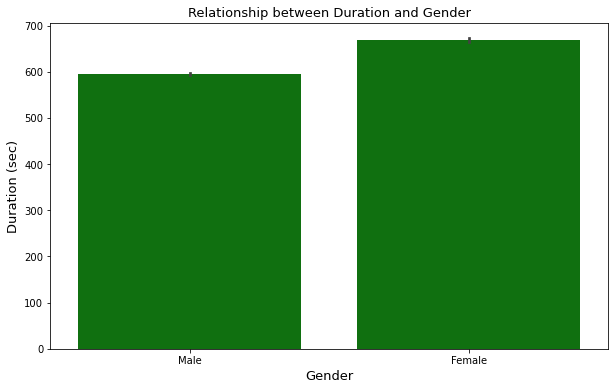

```python
plt.figure(figsize=(10,6))
sb.barplot(data = bike_clean[bike_clean['gender'] != "Other"], x = 'gender', y = 'duration_sec', color = 'green')
plt.xlabel('Gender', fontsize=13)
plt.ylabel('Duration (sec)', fontsize=13)
plt.title('Relationship between Duration and Gender', fontsize=13)
plt.show()
```

#### Observation 9:

> From the plot, the longest hours the male rode bike for is 590secs which is about 10mins while the longest the female rode bike for is about 670sec which is above 10mins. Therefore, female gender rode bike longer than the male gender

### Research Question 10: Among the bike user type, which gender rode the bike the most?

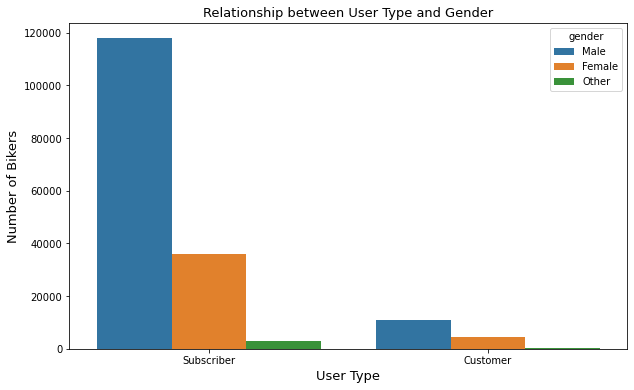

```python
plt.figure(figsize=(10,6))
sb.countplot(data =bike_clean, x = 'user_type', hue = 'gender');
plt.xlabel('User Type', fontsize=13)
plt.ylabel('Number of Bikers', fontsize=13)
plt.title('Relationship between User Type and Gender', fontsize=13)
plt.show()
```

#### Observation 10:

> For both user types (the subscribers and customers), the male gender rode bike MORE than the female gender.

### Research Question 11: What is the relationship between user type and duration in the dataset?

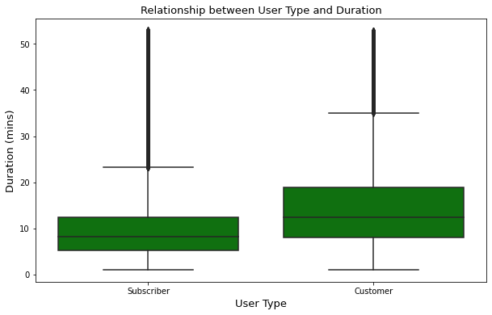

```python
plt.figure(figsize=(10,6))
sb.boxplot(data = bike_clean, x = 'user_type', y = 'duration_min', color = 'green')
plt.xlabel('User Type', fontsize=13)
plt.ylabel('Duration (mins)', fontsize=13)
plt.title('Relationship between User Type and Duration', fontsize=13)
plt.show()
```

#### Observation 11:

> Customers prefer to ride longer hours than subscribers

### Research Question 12: Which day of the week do bikers ride for long?

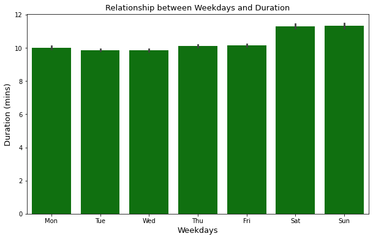

```python
plt.figure(figsize=(10,6))
sb.barplot(data = bike_clean, x = 'weekday', y = 'duration_min', order= week_order, color = 'green');
plt.xlabel('Weekdays', fontsize=13)
plt.ylabel('Duration (mins)', fontsize=13)
plt.title('Relationship between Weekdays and Duration', fontsize=13)
plt.show()
```

#### Observation 12:

> Riders prefer to ride for a long time on Saturday and Sundays than any other week days.

### Research Question 13: Is there a correlation between distance covered by bikers and the duration it takes for bikers to ride?

```python
print(f'The correlation between distance_km and duration_min is',
      bike_clean['duration_min'].corr(bike_clean['distance_km']).round(2))
```

```
The correlation between distance_km and duration_min is 0.6
```

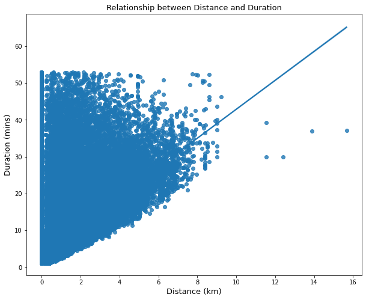

```python
plt.figure(figsize=(10,8))
sb.regplot(data = bike_clean, x = 'distance_km', y='duration_min')
plt.xlabel('Distance (km)', fontsize=13)
plt.ylabel('Duration (mins)', fontsize=13)
plt.title('Relationship between Distance and Duration', fontsize=13)
plt.show()
```

### Talk about some of the relationships you observed in this part of the investigation. How did the feature(s) of interest vary with other features in the dataset?

> - most likely customer riders would always send more time on the trip
> - female seems to spend more time on the trip
> - riders spend more time on Saturday and Sunday

### Did you observe any interesting relationships between the other features (not the main feature(s) of interest)?

> Weekdays affects bike rides as there are usually more riders on thurdays and fewer rides on saturday and sundays for subscribers and Wednesday and Saturdays for Customers. Also there are more male than the female in both subscribers and customers while subscribers population is about 90%

## Multivariate Exploration

```python
# convert user_type, gender, user_type and weekday into ordered categorical types
ordinal_var_dict = {'user_type': ['Customer', 'Subscriber'],
                    'gender': ['Male', 'Female', 'Other'],
                    'weekday': ['Mon','Tue','Wed','Thu','Fri','Sat','Sun']}

for var in ordinal_var_dict:
    ordered_var = pd.api.types.CategoricalDtype(ordered = True,
                                                categories = ordinal_var_dict[var])
    bike_clean[var] = bike_clean[var].astype(ordered_var)
```

```python
# Write a function to avoid repetition of code
def multi_catnum(num, cat1, cat2, kind, height, col_wrap):

    if kind == "bar" and height== None and col_wrap ==None:
        plt.figure(figsize=(13,11))
        ax = sb.barplot(data = bike_clean, x = cat1, y = num, hue = cat2, palette='rocket_r')
        plt.setp(ax.axes, xlabel= cat1, ylabel= num);
        plt.title(f"Effect of Biker's {cat1} and {cat2} on {num}");


    elif kind == "barf" and height == height and col_wrap==col_wrap:
        draw=sb.FacetGrid(data= bike_clean, col = cat1, margin_titles=True, col_wrap=col_wrap, height =height)
        draw.map(sb.barplot, num, cat2, color='purple')
        draw.fig.subplots_adjust(top=0.89);
        draw.fig.suptitle(f"Effect of Biker's {cat1} and {cat2} on {num}");
        plt.show()
```

### Research Question 14: Which day of the week do users spend the longest time riding bike?

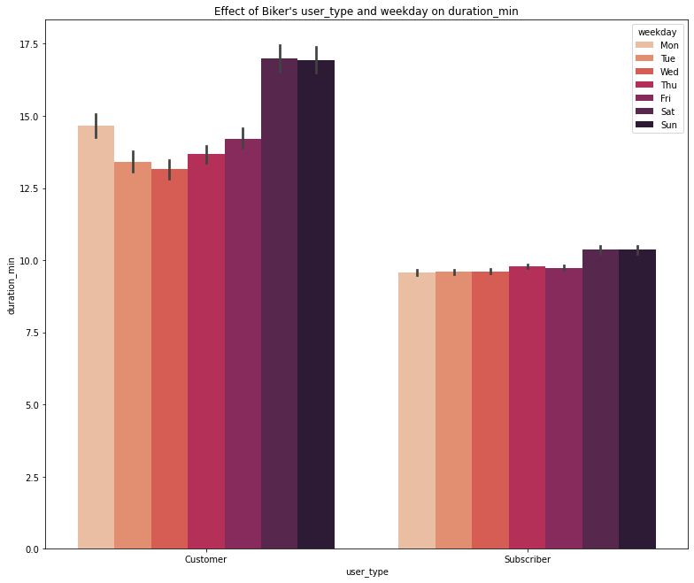

```python
multi_catnum('duration_min','user_type','weekday', kind='bar', height=None, col_wrap=None)
```

#### Observation 14:

> - The days of the weekday both customers and subscribers spent the longest time riding is on Saturdays
> - For customers, they spent the longest time on Saturdays and the shortest time on Wednesday riding bike
> - For subscribers, they spent the longest time on Saturdays and the shortest time on Mondays and Tuedays riding bike

### Research Question 15: Which day of the week do most gender spend the longest time riding bike?

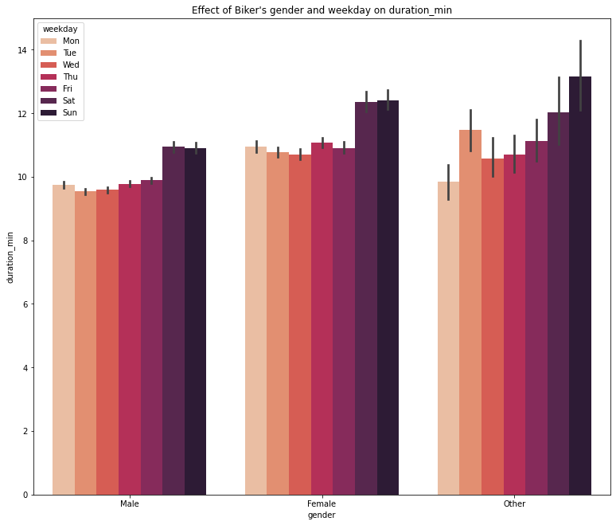

```python
multi_catnum('duration_min','gender','weekday', kind='bar', height=None, col_wrap=None)
```

#### Observation 15:

> - For the male gender, the day of the week they spent the longest time riding bike is on Saturdays and the shortest time on Tuesadys.
> - For the female gender, the day of the week they spent the longest time riding bike is on Sundays and the shortest time on Wednesdays.
> - For others, the day of the week they spent the longest time riding bike is on Sundays and the shortest time on Mondays.

### Research Question 16: Describe the relationship among user type and gender and the duration for riding bike?

```
C:\Users\Ecowatt NG\anaconda3\lib\site-packages\seaborn\axisgrid.py:670: UserWarning: Using the barplot function without specifying `order` is likely to produce an incorrect plot.
  warnings.warn(warning)
```

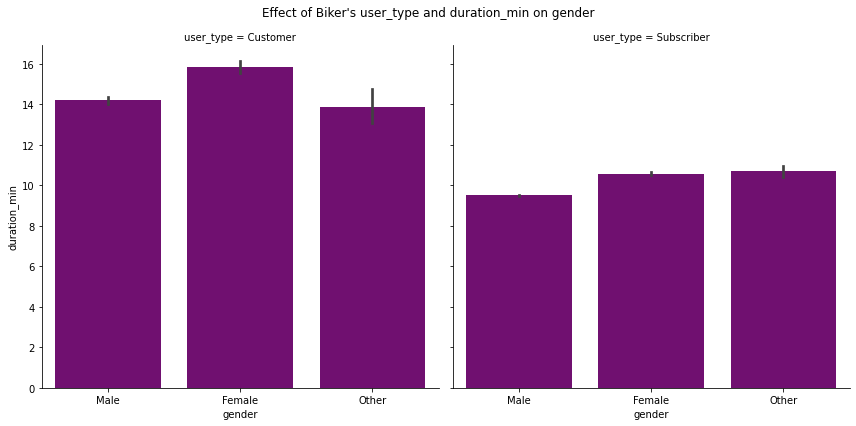

```python
multi_catnum('gender','user_type','duration_min', kind='barf', height=6, col_wrap=2)
```

[figure not shown]

```python
plt.figure(figsize=(10,6))
sb.barplot(data =bike_clean, x = 'user_type', y= 'duration_min', hue = 'gender');
plt.xlabel('User Type', fontsize=13)
plt.ylabel('Number of Bikers', fontsize=13)
plt.title('Relationship between User Type, Gender and Duration', fontsize=13)
plt.show()
```

#### Observation 16:

> - For customers, the gender that spent the longest time biking are female.
> - For subscribers, the gender that spent the longest time biking are others besides male and female.
> - Amongst all user type, irrespective of whether they are customers or subscribers, the gender that spent the longest time biking are female customers and those that spent the shortest time biking are male subscribers.

```
C:\Users\Ecowatt NG\anaconda3\lib\site-packages\seaborn\axisgrid.py:670: UserWarning: Using the barplot function without specifying `order` is likely to produce an incorrect plot.
  warnings.warn(warning)
```

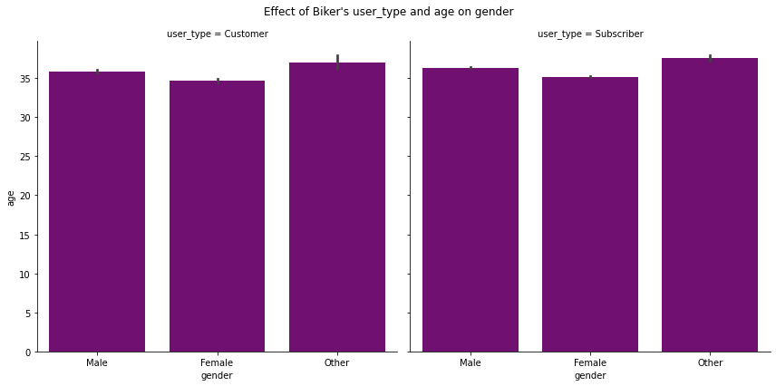

```python
multi_catnum('gender','user_type','age', kind='barf', height=6, col_wrap=2)
```

### Research Question 18: What is the relationship amongst Biker's User type, Distance and Duration?

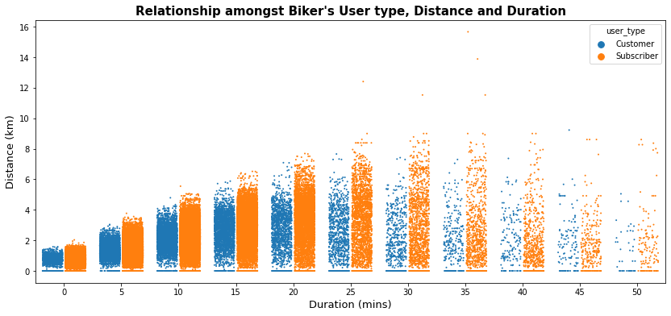

```python
plt.figure(figsize= [14, 6])
bike_clean['duration_min_int'] = ((bike_clean['duration_min']//5)*5).astype(int)
sb.stripplot(data = bike_clean, x='duration_min_int', y = 'distance_km', hue = 'user_type', size = 2, jitter = 0.35, dodge=True)
plt.xlabel('Duration (mins)', fontsize=13)
plt.ylabel('Distance (km)', fontsize=13)
plt.title("Relationship amongst Biker's User type, Distance and Duration",  fontsize = 15, fontweight = 'bold')
plt.show()
```

```
No artists with labels found to put in legend.  Note that artists whose label start with an underscore are ignored when legend() is called with no argument.
```

[figure not shown]

```python
plt.figure(figsize= [14, 6])
sb.regplot(data = bike_clean, y = 'duration_min', x = 'distance_km', scatter_kws = {'s' : 1}, line_kws = {'color':'orange' })

plt.xlabel('Duration (mins)', fontsize=13)
plt.ylabel('Distance (km)', fontsize=13)
plt.legend(title="gender_type")
plt.title("Relationship amongst Biker's Gender, Distance and Duration", fontsize=13)
plt.show()
```

## Conclusions

> The more the variables considered, the more accurate my prediction